# Bulk RNA-seq Differential Expression: Dexamethasone vs Untreated

Airway smooth muscle cells, 4 donors, paired design (DESeq2)

## About this dataset

Airway smooth muscle cells from 4 donors (`cellLine`), each with one `Untreated` sample and one `Dexamethasone`-treated sample (`treatment`) — the well-known “airway” dataset (Himes et al.). Gene-level counts come from RSEM (`data/rsem.merged.gene_counts.tsv`); sample metadata is in `data/experiment_table.csv`.

Because each donor contributes both conditions, this is a **paired design**: the model below blocks on `cellLine` so that donor-to-donor variability doesn’t obscure the treatment effect.

```r
library(DESeq2)
library(apeglm)
library(dplyr)
library(readr)
library(tidyr)
library(tibble)
library(ggplot2)
library(ggrepel)
library(pheatmap)
library(RColorBrewer)
library(AnnotationDbi)
library(org.Hs.eg.db)

# Thresholds for calling a gene "significant" — change these to re-run with different cutoffs.
PADJ_THRESHOLD <- 0.05
LFC_THRESHOLD <- 1
```

## Load and prepare data

```r
counts_raw <- read_tsv("data/rsem.merged.gene_counts.tsv", show_col_types = FALSE)

count_mat <- counts_raw |>
  dplyr::select(-`transcript_id(s)`) |>
  column_to_rownames("gene_id") |>
  as.matrix()

# RSEM reports non-integer "expected counts" (e.g. 340.80); DESeq2 requires integer counts.
count_mat <- round(count_mat)

coldata <- read_csv("data/experiment_table.csv", show_col_types = FALSE) |>
  column_to_rownames("ID")

# Align sample order and hard-fail if the ID join between the two files doesn't line up.
count_mat <- count_mat[, rownames(coldata)]
stopifnot(identical(colnames(count_mat), rownames(coldata)))

# "Untreated" as the reference level so fold changes read as Dexamethasone vs Untreated.
coldata$treatment <- factor(coldata$treatment, levels = c("Untreated", "Dexamethasone"))
coldata$cellLine <- factor(coldata$cellLine)

coldata
```

|  | cellLine | treatment |
| --- | --- | --- |
| SRR1039508 | N61311 | Untreated |
| SRR1039509 | N61311 | Dexamethasone |
| SRR1039512 | N052611 | Untreated |
| SRR1039513 | N052611 | Dexamethasone |
| SRR1039516 | N080611 | Untreated |
| SRR1039517 | N080611 | Dexamethasone |
| SRR1039520 | N061011 | Untreated |
| SRR1039521 | N061011 | Dexamethasone |

```r
keep <- rowSums(count_mat) >= 10
cat(sprintf(
  "Keeping %d of %d genes after low-count filtering (rowSums >= 10).\n",
  sum(keep), length(keep)
))
```

```
Keeping 20803 of 58735 genes after low-count filtering (rowSums >= 10).
```

```r
count_mat <- count_mat[keep, ]
```

```r
dds <- DESeqDataSetFromMatrix(
  countData = count_mat,
  colData = coldata,
  design = ~ cellLine + treatment
)
dds
```

```
class: DESeqDataSet
dim: 20803 8
metadata(1): version
assays(1): counts
rownames(20803): ENSG00000000003 ENSG00000000419 ... ENSG00000285979
  ENSG00000285991
rowData names(0):
colnames(8): SRR1039508 SRR1039509 ... SRR1039520 SRR1039521
colData names(2): cellLine treatment
```

## Quality control

### Library sizes

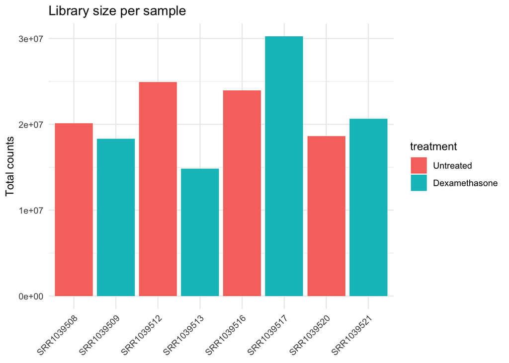

Total counts per sample

```r
lib_sizes <- colSums(counts(dds)) |>
  enframe(name = "sample", value = "library_size") |>
  left_join(as.data.frame(colData(dds)) |> rownames_to_column("sample"), by = "sample")

ggplot(lib_sizes, aes(x = sample, y = library_size, fill = treatment)) +
  geom_col() +
  labs(title = "Library size per sample", x = NULL, y = "Total counts") +
  theme_minimal() +
  theme(axis.text.x = element_text(angle = 45, hjust = 1))
```

### PCA

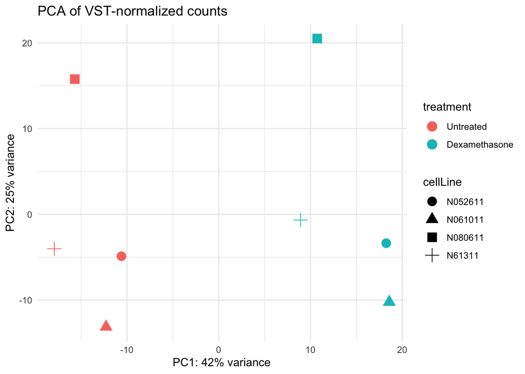

PCA of VST-normalized counts

```r
vsd <- vst(dds, blind = TRUE)

pca_data <- plotPCA(vsd, intgroup = c("treatment", "cellLine"), returnData = TRUE)
percent_var <- round(100 * attr(pca_data, "percentVar"))

ggplot(pca_data, aes(x = PC1, y = PC2, color = treatment, shape = cellLine)) +
  geom_point(size = 4) +
  labs(
    x = paste0("PC1: ", percent_var[1], "% variance"),
    y = paste0("PC2: ", percent_var[2], "% variance"),
    title = "PCA of VST-normalized counts"
  ) +
  theme_minimal()
```

### Sample-to-sample distances

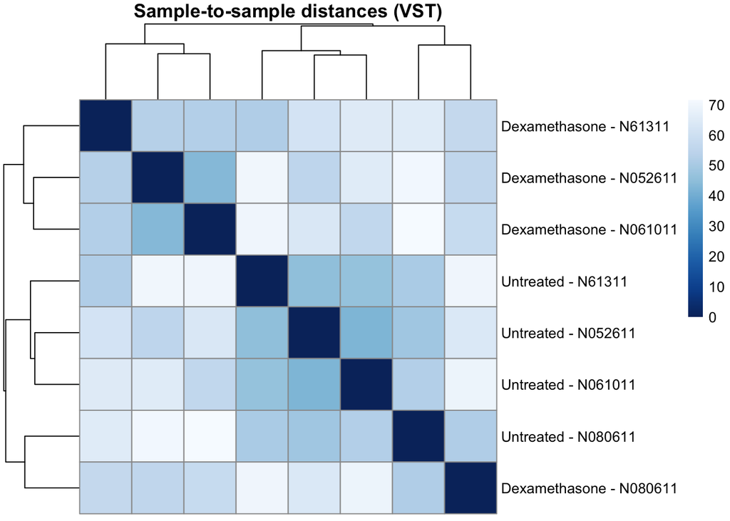

Sample-to-sample distances (VST)

```r
sample_dist <- dist(t(assay(vsd)))
dist_mat <- as.matrix(sample_dist)
rownames(dist_mat) <- paste(vsd$treatment, vsd$cellLine, sep = " - ")
colnames(dist_mat) <- NULL

colors <- colorRampPalette(rev(brewer.pal(9, "Blues")))(255)
pheatmap(
  dist_mat,
  clustering_distance_rows = sample_dist,
  clustering_distance_cols = sample_dist,
  col = colors,
  main = "Sample-to-sample distances (VST)"
)
```

## Differential expression

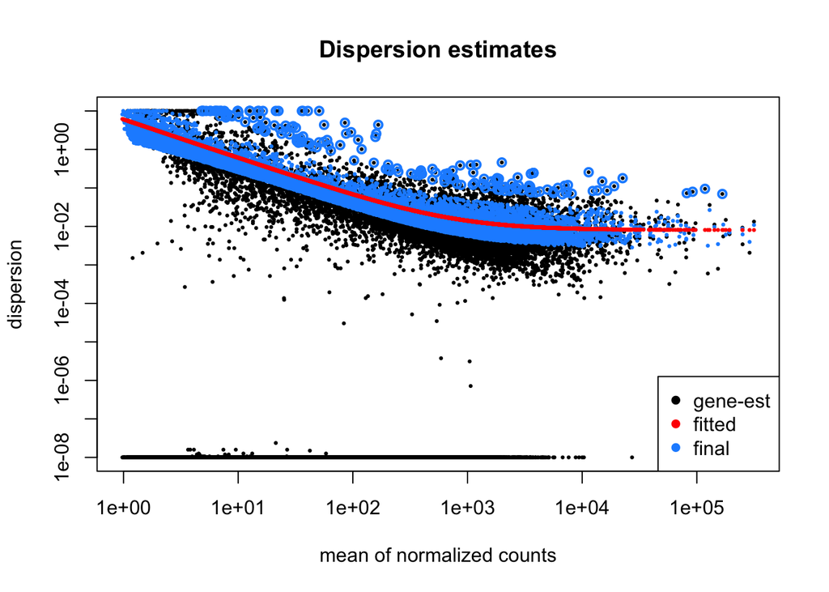

```r
dds <- DESeq(dds)
plotDispEsts(dds, main = "Dispersion estimates")
```

```r
res <- results(dds, contrast = c("treatment", "Dexamethasone", "Untreated"), alpha = PADJ_THRESHOLD)
summary(res)
```

```
out of 20803 with nonzero total read count
adjusted p-value < 0.05
LFC > 0 (up)       : 2193, 11%
LFC < 0 (down)     : 1724, 8.3%
outliers [1]       : 0, 0%
low counts [2]     : 4840, 23%
(mean count < 8)
[1] see 'cooksCutoff' argument of ?results
[2] see 'independentFiltering' argument of ?results
```

Shrink the log2 fold changes with `apeglm` — this pulls in noisy fold-change estimates for low-count genes without touching genes with strong evidence, which is why the coefficient below is used for reporting/plots rather than the raw Wald-test result above.

```r
stopifnot("treatment_Dexamethasone_vs_Untreated" %in% resultsNames(dds))
res_shrunk <- lfcShrink(dds, coef = "treatment_Dexamethasone_vs_Untreated", type = "apeglm")
```

### Annotate with gene symbols

The count matrix only has Ensembl gene IDs. We map them to gene symbols via `org.Hs.eg.db`, keeping both columns in every output table — symbol for readability, Ensembl ID as the unambiguous key (some IDs won’t have a current symbol; those fall back to showing the Ensembl ID).

```r
symbols <- mapIds(org.Hs.eg.db, keys = rownames(res_shrunk), column = "SYMBOL", keytype = "ENSEMBL", multiVals = "first")

res_df <- as.data.frame(res_shrunk) |>
  rownames_to_column("gene_id") |>
  as_tibble() |>
  mutate(
    symbol = symbols[gene_id],
    label = if_else(is.na(symbol), gene_id, symbol),
    significant = !is.na(padj) & padj < PADJ_THRESHOLD & abs(log2FoldChange) >= LFC_THRESHOLD
  ) |>
  relocate(symbol, .after = gene_id) |>
  arrange(padj)

n_sig <- sum(res_df$significant, na.rm = TRUE)
cat(sprintf(
  "%d genes significant at padj < %.2f and |log2FC| >= %.1f\n",
  n_sig, PADJ_THRESHOLD, LFC_THRESHOLD
))
```

```
773 genes significant at padj < 0.05 and |log2FC| >= 1.0
```

```r
res_df
```

| gene_id | symbol | baseMean | log2FoldChange | lfcSE | pvalue | padj | label | significant |
| --- | --- | --- | --- | --- | --- | --- | --- | --- |
| ENSG00000165995 | CACNB2 | 5.194501e+02 | 3.306689528 | 0.13496663 | 1.036085e-133 | 1.737410e-129 | CACNB2 | TRUE |
| ENSG00000152583 | SPARCL1 | 9.684210e+02 | 4.558916573 | 0.18838756 | 1.964926e-132 | 1.647492e-128 | SPARCL1 | TRUE |
| ENSG00000120129 | DUSP1 | 3.205418e+03 | 2.936068504 | 0.12261773 | 6.942616e-129 | 3.880691e-125 | DUSP1 | TRUE |
| ENSG00000162614 | NEXN | 5.187692e+03 | 2.019400580 | 0.08509201 | 6.860415e-126 | 2.876057e-122 | NEXN | TRUE |
| ENSG00000157214 | STEAP2 | 2.822411e+03 | 1.966435381 | 0.08311832 | 4.777924e-125 | 1.602420e-121 | STEAP2 | TRUE |
| ENSG00000101347 | SAMHD1 | 1.363247e+04 | 3.742908192 | 0.16264424 | 1.790446e-120 | 5.003999e-117 | SAMHD1 | TRUE |
| ENSG00000189221 | MAOA | 2.272615e+03 | 3.332761496 | 0.14575096 | 2.540657e-118 | 6.086325e-115 | MAOA | TRUE |
| ENSG00000196136 | SERPINA3 | 2.598478e+03 | 3.199404213 | 0.14882737 | 7.979098e-105 | 1.672519e-101 | SERPINA3 | TRUE |
| ENSG00000211445 | GPX3 | 1.193636e+04 | 3.711029301 | 0.17360370 | 9.490811e-105 | 1.768349e-101 | GPX3 | TRUE |
| ENSG00000125148 | MT2A | 3.526928e+03 | 2.189637959 | 0.10506078 | 3.443928e-98 | 5.775122e-95 | MT2A | TRUE |

[output cut: 9990 more lines]

### Sanity check against known biology

`FKBP5`, `TSC22D3`, `DUSP1`, and `PER1` are well-established glucocorticoid-responsive genes in this dataset — they should show up here as strongly, significantly upregulated. If they don’t, something upstream (sample/ID alignment, factor levels, contrast direction) is wrong.

```r
res_df |>
  filter(symbol %in% c("FKBP5", "TSC22D3", "DUSP1", "PER1")) |>
  dplyr::select(gene_id, symbol, log2FoldChange, padj, significant)
```

| gene_id | symbol | log2FoldChange | padj | significant |
| --- | --- | --- | --- | --- |
| ENSG00000120129 | DUSP1 | 2.936069 | 3.880691e-125 | TRUE |
| ENSG00000179094 | PER1 | 3.174895 | 7.548671e-73 | TRUE |
| ENSG00000096060 | FKBP5 | 3.967617 | 7.295385e-26 | TRUE |
| ENSG00000157514 | TSC22D3 | 3.111816 | 1.319941e-19 | TRUE |

## Visualization

### MA plot

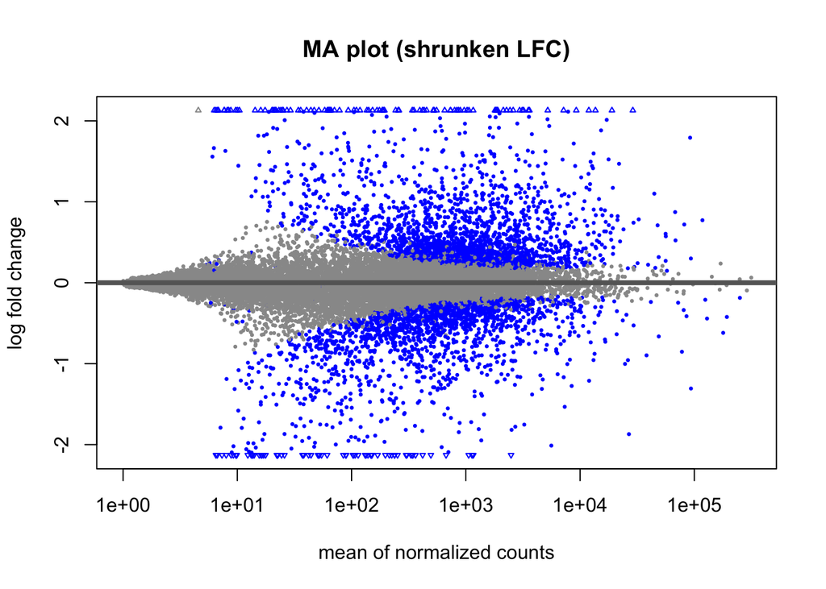

MA plot (shrunken log2 fold changes)

```r
plotMA(res_shrunk, alpha = PADJ_THRESHOLD, main = "MA plot (shrunken LFC)")
```

### Volcano plot

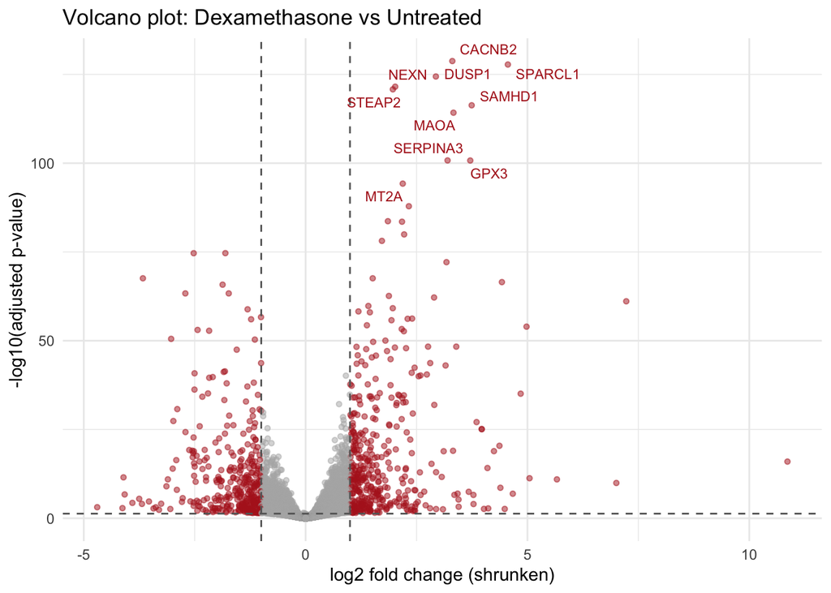

Volcano plot: Dexamethasone vs Untreated

```r
plot_df <- res_df |> filter(!is.na(padj))
top_labels <- plot_df |> filter(significant) |> slice_min(padj, n = 10)

ggplot(plot_df, aes(x = log2FoldChange, y = -log10(padj), color = significant)) +
  geom_point(alpha = 0.5, size = 1.2) +
  scale_color_manual(values = c(`TRUE` = "firebrick", `FALSE` = "grey70"), guide = "none") +
  geom_vline(xintercept = c(-LFC_THRESHOLD, LFC_THRESHOLD), linetype = "dashed", color = "grey40") +
  geom_hline(yintercept = -log10(PADJ_THRESHOLD), linetype = "dashed", color = "grey40") +
  geom_text_repel(data = top_labels, aes(label = label), size = 3, max.overlaps = 20) +
  labs(
    title = "Volcano plot: Dexamethasone vs Untreated",
    x = "log2 fold change (shrunken)", y = "-log10(adjusted p-value)"
  ) +
  theme_minimal()
```

### Heatmap of top differentially expressed genes

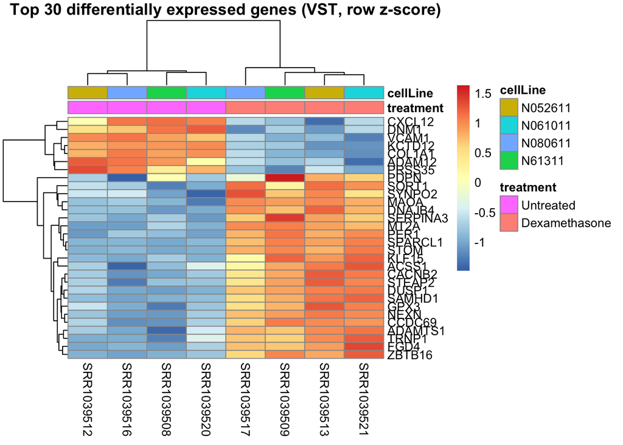

Top 30 differentially expressed genes (VST, row z-score)

```r
top_genes <- plot_df |> slice_min(padj, n = 30) |> pull(gene_id)

mat <- assay(vsd)[top_genes, ]
mat <- t(scale(t(mat)))
rownames(mat) <- res_df$label[match(top_genes, res_df$gene_id)]

annotation_col <- as.data.frame(colData(vsd)[, c("treatment", "cellLine")])

pheatmap(
  mat,
  annotation_col = annotation_col,
  show_rownames = TRUE,
  main = "Top 30 differentially expressed genes (VST, row z-score)"
)
```

## Export results

```r
dir.create("results", showWarnings = FALSE)

write_csv(res_df, "results/de_results_all.csv")
write_csv(filter(res_df, significant), "results/de_results_significant.csv")

norm_counts <- counts(dds, normalized = TRUE) |>
  as.data.frame() |>
  rownames_to_column("gene_id")
write_csv(norm_counts, "results/normalized_counts.csv")

cat("Wrote results/de_results_all.csv, results/de_results_significant.csv, results/normalized_counts.csv\n")
```

```
Wrote results/de_results_all.csv, results/de_results_significant.csv, results/normalized_counts.csv
```